# OTN/CANSSI Datathon: scalloped hammerhead sharks

Arauz, R., Steiner, T., Chávez, E.J., Hearn, A.

## Data availability statement

The dataset for this activity is available in the file *hammerhead_sharks_Arauz_etal.csv* shared via Github (https://github.com/MarieAugerMethe/CANSSI_OTN_HMM_2023). It can used for our OTN/CANSSI meeting and shared for educational purposes with accreditation (*Arauz, R., Steiner, T., Chávez, E.J., Hearn, A*). It cannot be used for any publication without written permission. Please contact *Randall Arauz* (*rarauz@cremacr.org*) or *Elpis Joan* (*elpis_joan@hotmail.com*) for more information.

## Set up

Let’s load some of the packages needed.

```r
library(ggplot2)
library(tidyr)
library(dplyr)
library(lubridate)
```

## Description of the dataset

This data set contains the detections of 5 female hammerhead shark individuals tagged with V16 acoustic transmitters at Cocos Island (Costa Rica) in August 2017. This data set was extracted from a larger data set of 70 hammerhead shark individuals tagged between 2015 and 2021 by Randall Arauz and collaborators. An array of 8 acoustic receivers was placed around Cocos Island to detect the signals from the acoustic transmitters which were programmed to emit random signals every 2 to 5 minutes. We subsetted the data to last from the deployment to March 1 2019.

Let’s read the data into R and have a quick peak at it.

```r
shark <- read.csv("hammerhead_sharks_Arauz_etal.csv")
head(shark)
```

```
##   Tag_Id   Date_tag        Datetime_det Station.Name    Lat     Long Depth
## 1  30571 2017-08-06 2017-12-10 13:24:00    Manuelita 5.5617 -87.0489    30
## 2  30571 2017-08-06 2017-12-10 13:25:00    Manuelita 5.5617 -87.0489    30
## 3  30571 2017-08-06 2017-12-10 13:26:00    Manuelita 5.5617 -87.0489    30
## 4  30571 2017-08-06 2017-12-10 13:34:00    Manuelita 5.5617 -87.0489    30
## 5  30571 2017-08-06 2017-12-10 13:36:00    Manuelita 5.5617 -87.0489    30
## 6  30571 2017-08-06 2017-12-10 13:37:00    Manuelita 5.5617 -87.0489    30
##   mean.chla     sd.chla mean.temp
## 1 0.1194317 0.008932947     26.92
## 2 0.1194317 0.008932947     26.92
## 3 0.1194317 0.008932947     26.92
## 4 0.1194317 0.008932947     26.92
## 5 0.1194317 0.008932947     26.92
## 6 0.1194317 0.008932947     26.92
```

As you can see, the dataset contains these variables:

- **Tag_Id:** Identification code of the tag used for each individual
- **Date_tag:** Date at which each individual was tagged
- **Datetime_det:** Date and time associated to each detection
- **Station.Name:** Site of detection. The acoustic receivers were placed at 8 sites around the island (Roca Sucia, Alcyone, Dos Amigos, Manuelita, Canal, Punta Maria, Ulloa and Shark fin)
- **Lat:** Latitude of the receiver’s location
- **Long:** Longitude of the receiver’s location
- **Depth:** Depth of the receiver from the surface
- **mean.chla:** Mean chlorophyll-a concentrations (mg m-3) with a spatial resolution of 4.64 km and monthly composite extracted from NASA’s Aqua Spacecraft (https://www.pfeg.noaa.gov)
- **sd.chla:** SD chlorophyll-a concentration (?)
- **mean.temp:** Daily mean sea surface temperature (ºC) with a spatial resolution of 0.25 degrees from NOAA NCEI (https://www.ncdc.noaa.gov/oisst)

The main movement variable we will model are the coordinates of the station where each individual was detected (Lat, Long). The data are detections of the individuals that come within the range of a receiver. The tag are programmed to emit their ID between 2 and 5 min, but the detections are made when the shark comes within the range of the receiver. Thus the data is at irregular time intervals.

Let’s do some basic formatting. `Tag_Id` as factor and `Datetime_det` as datetime.

```r
shark$Datetime_det <- ymd_hms(shark$Datetime_det)
shark$Tag_Id <- as.factor(shark$Tag_Id)
```

Let’s look at the time intervals between detections

```r
time_int <- shark %>% group_by(Tag_Id) %>% summarise(dt = diff(Datetime_det))
range(time_int$dt)
```

```
## Time differences in secs
## [1]       0 9438300
```

```r
# How many longer than 30 min
sum(time_int$dt > 30*60)
```

```
## [1] 2493
```

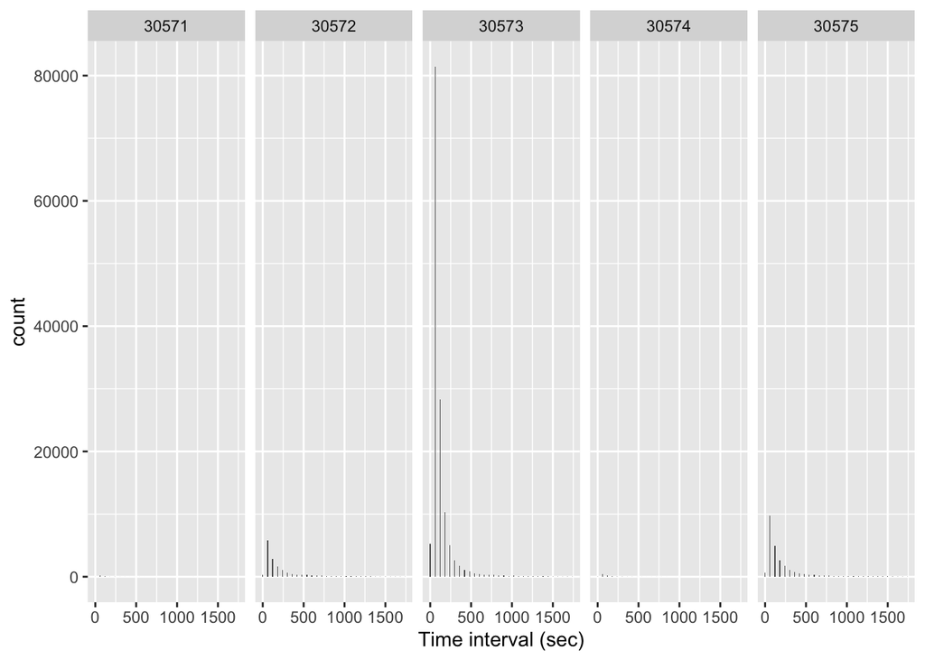

```r
# Plot the intevals for shorter time periods (< 30 min)
ggplot(filter(time_int, dt < 30*60), aes(as.numeric(dt))) +
  geom_histogram(binwidth = 10) +
  xlab("Time interval (sec)") +
  facet_grid(~ Tag_Id)
```

## Quick data exploration

Let’s quickly visualize it.

Let’s map the data

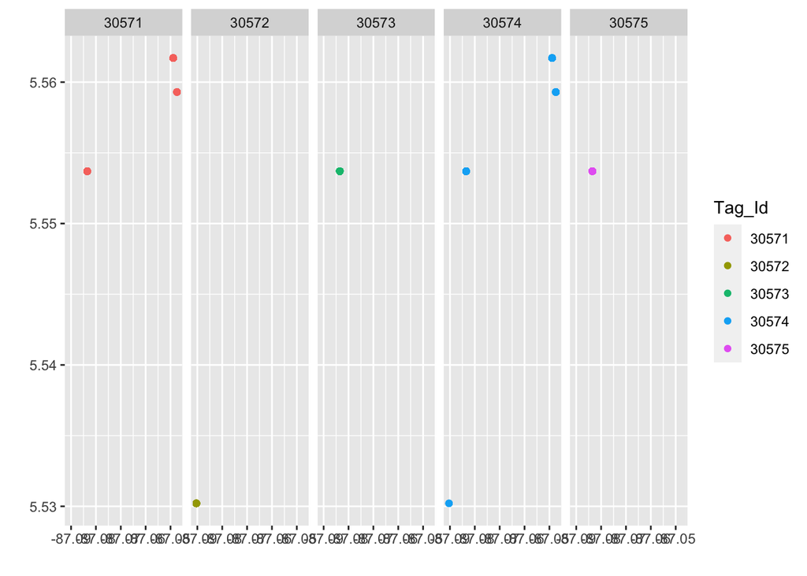

```r
# Map the data
ggplot() +
  xlab('') + ylab('') +
  geom_point(data = shark, aes(x=Long, y=Lat, colour = Tag_Id)) +
  facet_grid(~ Tag_Id)
```

Not very informative as there are only 8 receivers, and as we can see only 4 receivers detected sharks during that time period. From the map however, we can see that the sharks used different receivers.

```r
# Which receivers detected shark?
unique(shark$Station.Name)
```

```
## [1] "Manuelita"   "Canal"       "Roca Sucia"  "Punta Maria"
```

Let’s look at diurnal and monthly patterns.

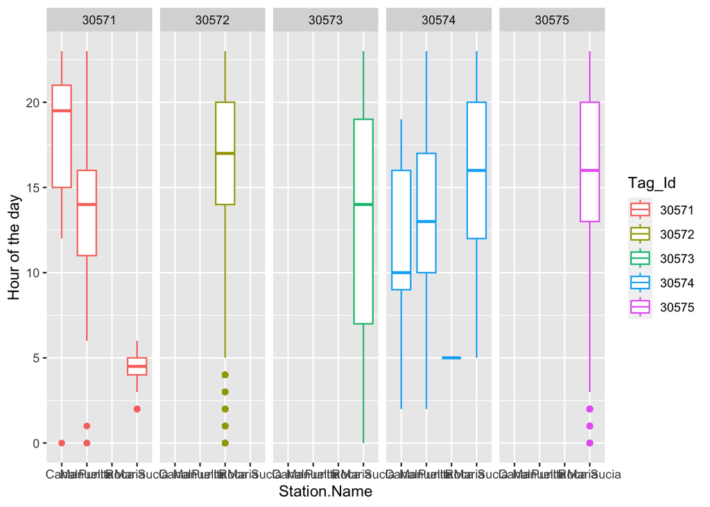

```r
ggplot(shark, aes(x=Station.Name, y=hour(Datetime_det), colour=Tag_Id)) +
  geom_boxplot() +
  ylab("Hour of the day") +
  facet_grid(~ Tag_Id)
```

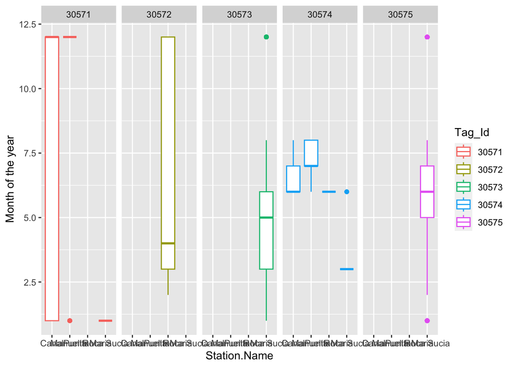

```r
ggplot(shark, aes(x=Station.Name, y=month(Datetime_det), colour=Tag_Id)) +
  geom_boxplot() +
  ylab("Month of the year") +
  facet_grid(~ Tag_Id)
```

Look at days with detections

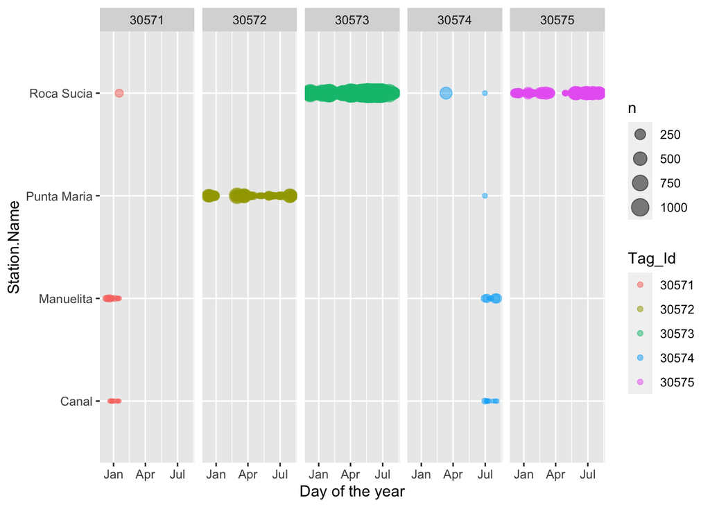

```r
# Look at days with detection
shark$Date_det <- date(shark$Datetime_det)
shark_res <- unique(shark[,c("Tag_Id", "Date_tag",
                                 "Station.Name",
                                 "Lat", "Long", "Depth",
                                 "Date_det",
                                 "mean.chla", "sd.chla", "mean.temp")])

# Look at the number of detections on these days
shark_res <- shark %>% group_by(Tag_Id, Station.Name) %>% count(Date_det) %>%
  full_join(shark_res, by= c("Tag_Id", "Date_det", "Station.Name"))


ggplot(shark_res, aes(x=Date_det, y=Station.Name, colour=Tag_Id)) +
  geom_point(aes(size=n), alpha=0.5) +
  xlab("Day of the year") +
  facet_grid(~ Tag_Id)
```

```r
# n is the number of detections per day for that individual at that receiver
```

## Datathon goal

The goals are (1) to provide a road map of how to tackle the questions listed below, (2) attempt to complete at least the first step of your road map, and (3) provide interpretation of the results. Make a quick 5-minute presentation explaining what your team did.

### Questions:

1. Evaluate movement patterns and residency of scalloped hammerhead sharks at Cocos Island
2. Determine the influence of surface temperature and chlorophyll-a concentration on the residency of scalloped hammerhead sharks at Cocos Island